# Exercise18

## Exercise 18

Prostate-specific antigen (PSA) is an enzyme whose level is used as a (controversial) indicator of prostate cancer; however, a high level may also indicate other prostate diseases. The Prostate data set examines the correlation between PSA levels and other clinical measures in men who were about to receive a radical prostatectomy. The data set is included in the R package lasso2 and can be loaded as follows:

```r
data(Prostate, package = "lasso2")
summary(Prostate)
```

```
##      lcavol           lweight           age             lbph
##  Min.   :-1.3471   Min.   :2.375   Min.   :41.00   Min.   :-1.3863
##  1st Qu.: 0.5128   1st Qu.:3.376   1st Qu.:60.00   1st Qu.:-1.3863
##  Median : 1.4469   Median :3.623   Median :65.00   Median : 0.3001
##  Mean   : 1.3500   Mean   :3.653   Mean   :63.87   Mean   : 0.1004
##  3rd Qu.: 2.1270   3rd Qu.:3.878   3rd Qu.:68.00   3rd Qu.: 1.5581
##  Max.   : 3.8210   Max.   :6.108   Max.   :79.00   Max.   : 2.3263
##       svi              lcp             gleason          pgg45
##  Min.   :0.0000   Min.   :-1.3863   Min.   :6.000   Min.   :  0.00
##  1st Qu.:0.0000   1st Qu.:-1.3863   1st Qu.:6.000   1st Qu.:  0.00
##  Median :0.0000   Median :-0.7985   Median :7.000   Median : 15.00
##  Mean   :0.2165   Mean   :-0.1794   Mean   :6.753   Mean   : 24.38
##  3rd Qu.:0.0000   3rd Qu.: 1.1787   3rd Qu.:7.000   3rd Qu.: 40.00
##  Max.   :1.0000   Max.   : 2.9042   Max.   :9.000   Max.   :100.00
##       lpsa
##  Min.   :-0.4308
##  1st Qu.: 1.7317
##  Median : 2.5915
##  Mean   : 2.4784
##  3rd Qu.: 3.0564
##  Max.   : 5.5829
```

1. Fit a linear model to the data set using LASSO regression. Use the function cv.glmnet from the R package glmnet. Which is the optimal regularization parameter lambda ? Which coeficients are non-zero in the corresponding model?

```r
library("glmnet")
```

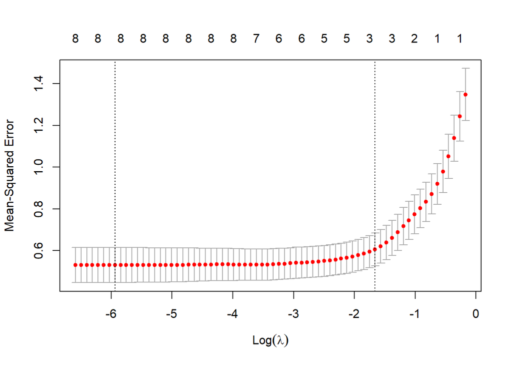

```r
X <- as.matrix(Prostate[,-ncol(Prostate)])
set.seed(1234)
prostate.lasso.cv <- cv.glmnet(X, Prostate$lpsa)
plot(prostate.lasso.cv)
```

Lambda is very low at its minimum.

```r
prostate.lasso.cv$lambda.min
```

```
## [1] 0.002636315
```

How to chose the lambda: https://www.youtube.com/watch?v=8oEZkHqf_Rk&list=PLOg0ngHtcqbPTlZzRHA2ocQZqB1D_qZ5V&index=36&t=0s Here they use cross-validation (CV)

It is better to take the biggest lambda within 1sd of the smallest MSE

```r
prostate.lasso.cv$lambda.1se
```

```
## [1] 0.1903632
```

Here are the coefficients:

```r
coef(prostate.lasso.cv)
```

```
## 9 x 1 sparse Matrix of class "dgCMatrix"
##                     1
## (Intercept) 1.0785980
## lcavol      0.4720240
## lweight     0.1869505
## age         .
## lbph        .
## svi         0.3680476
## lcp         .
## gleason     .
## pgg45       .
```

b

2. Fit a linear model using ridge regression. Use again the function cv.glmnet, this time with parameter alpha = 0. Which is the optimal regularization parameter lambda here?

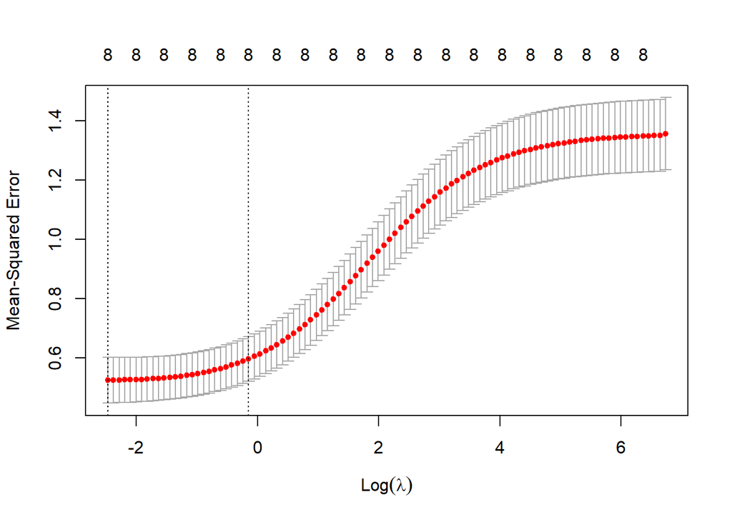

```r
set.seed(1234)
prostate.ridge.cv <- cv.glmnet(X, Prostate$lpsa, alpha = 0)
plot(prostate.ridge.cv)
```

Again to find the one standard error rule lambda:

```r
prostate.ridge.cv$lambda.1se
```

```
## [1] 0.8632742
```

```r
coef(prostate.ridge.cv)
```

```
## 9 x 1 sparse Matrix of class "dgCMatrix"
##                        1
## (Intercept)  0.343685458
## lcavol       0.282478220
## lweight      0.320266558
## age         -0.002302283
## lbph         0.055899131
## svi          0.469634169
## lcp          0.075834229
## gleason      0.084708881
## pgg45        0.002660752
```

c Plot the LASSO and ridge traces of the models from a) and b) side-by-side. What are the differences, and where do they come from?

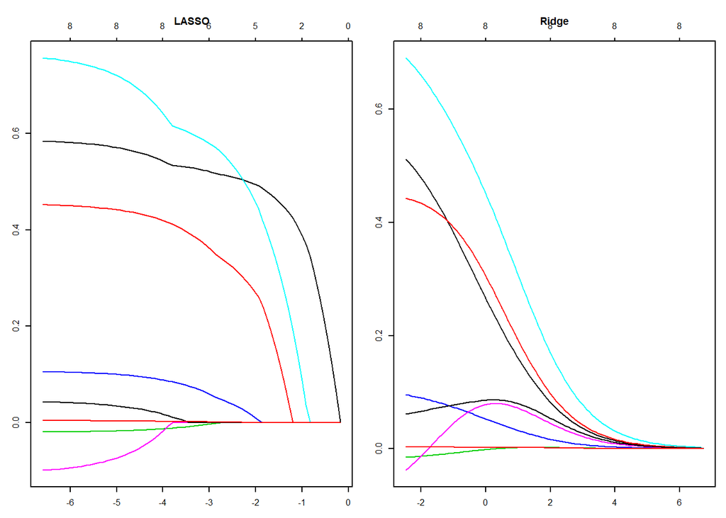

```r
set.seed(7)
pro.lasso <- glmnet(X, Prostate$lpsa, alpha = 1)
set.seed(7)
pro.ridge <- glmnet(X, Prostate$lpsa, alpha = 0)
par(mfrow = c(1, 2), cex = 0.5, mar = c(3, 3, 4, 1))
plot(pro.lasso, xvar = "lambda", main = "LASSO")
plot(pro.ridge, xvar = "lambda", main = "Ridge")
```

Elastic net

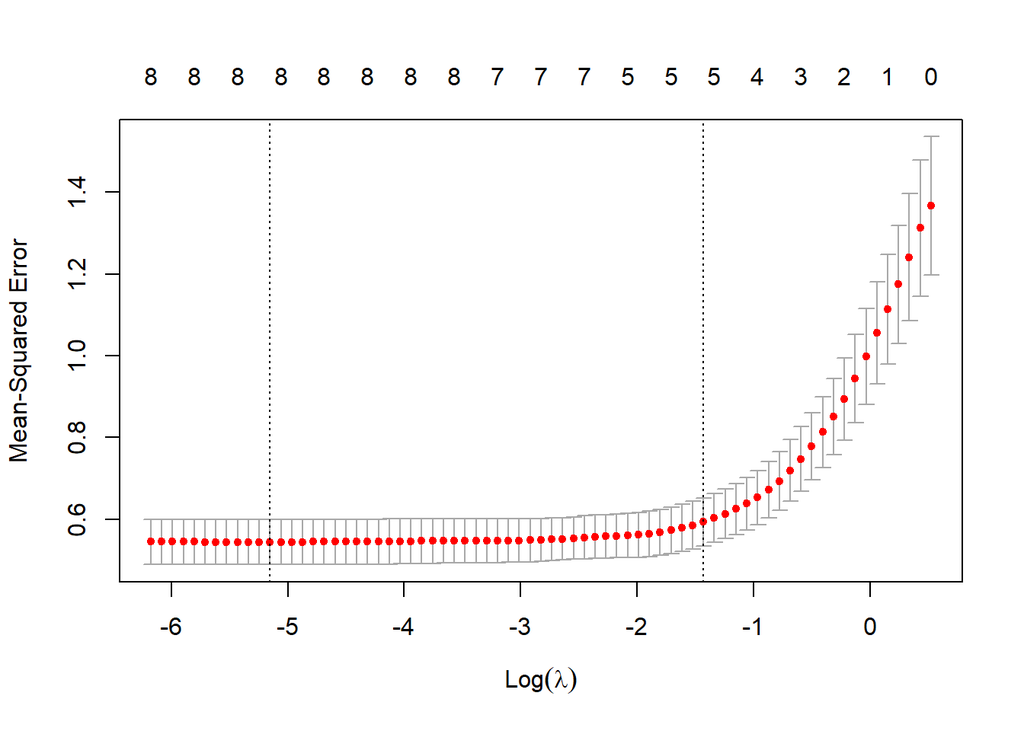

```r
set.seed(7)
pro.net.cv <- cv.glmnet(X, Prostate$lpsa, alpha = 0.5)
plot(pro.net.cv)
```